# MPDW P1

Farhan Abdillah Harahap

2023-08-31

##Library

```r
library("forecast")
```

```r
library("graphics")
library("TTR")
library("TSA")
library(rio)
```

##Read Data

```r
data<- import("https://raw.githubusercontent.com/farhanabdillahh/PraktikumMPDW/main/data/datasetmpdw.csv")
View(data)
str(data)
```

```
## 'data.frame':    365 obs. of  2 variables:
##  $ date : chr  "01/06/2022" "02/06/2022" "03/06/2022" "04/06/2022" ...
##  $ value: num  31.6 31.5 30.5 29.3 29.1 ...
```

```r
dim(data)
```

```
## [1] 365   2
```

## Data deret waktu

```r
data1.ts <- ts(data$value)
```

## Eksplorasi Data

```r
summary(data1.ts)
```

```
##    Min. 1st Qu.  Median    Mean 3rd Qu.    Max.
##   25.89   29.52   30.52   30.55   31.59   34.67
```

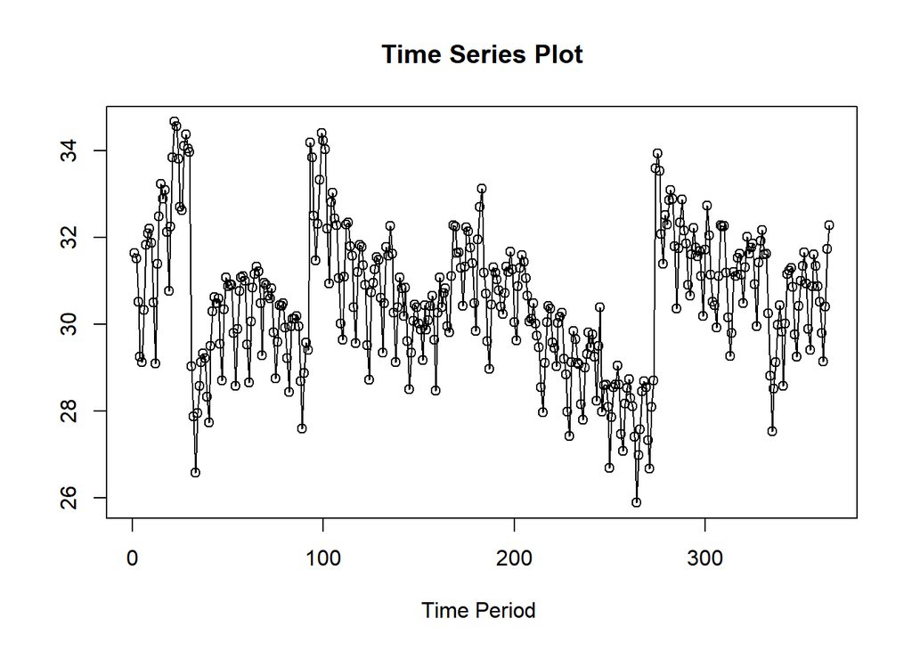

```r
ts.plot(data1.ts, xlab="Time Period ", ylab="",
        main = "Time Series Plot")
points(data1.ts)
```

##Uji Kestasioneran H0 : data tidak stasioner H1 : data stasioner

```r
library(tseries)
adf.test(data1.ts, k = 3)
```

```
##
##  Augmented Dickey-Fuller Test
##
## data:  data1.ts
## Dickey-Fuller = -5.2406, Lag order = 3, p-value = 0.01
## alternative hypothesis: stationary
```

```r
adf.test(data1.ts, k = 12)
```

```
##
##  Augmented Dickey-Fuller Test
##
## data:  data1.ts
## Dickey-Fuller = -3.2222, Lag order = 12, p-value = 0.08439
## alternative hypothesis: stationary
```

Pada taraf nyata 10%, Data tergolong stasioner dengan lag order = 3 dan 12. Pada taraf nyata 5%, Data tidak tergolong stasioner dengan lag order = 12. Olah karena itu, selanjutnya akan dilakukan pemodelan SMA dan DMA dengan m = 3 dan m = 12

##Single Moving Average dan Double Moving Average SMA -> Data Stasioner DMA -> Data berpola trend ###Split Data

```r
training<-data[1:292,]
testing<-data[293:365,]
train.ts<-ts(training$value)
test.ts<-ts(testing$value)
```

### Eksplorasi Data

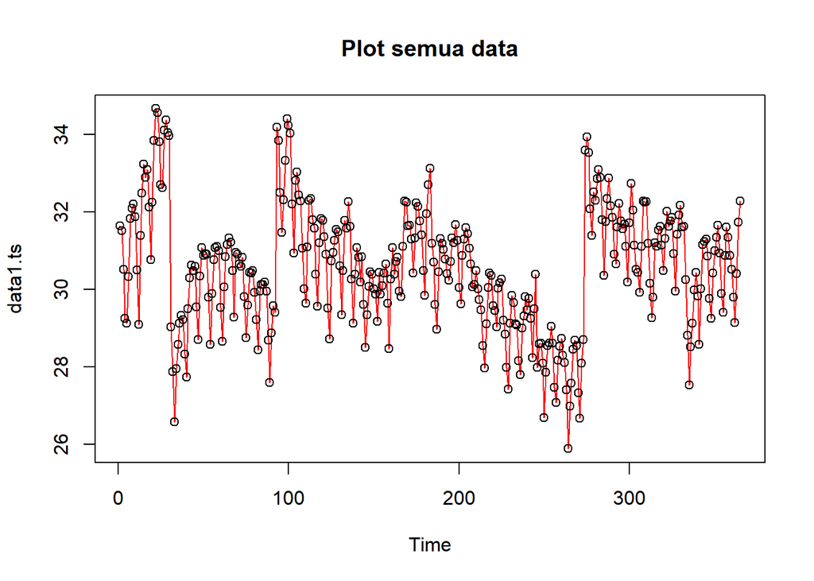

```r
#eksplorasi keseluruhan data
plot(data1.ts, col="red",main="Plot semua data")
points(data1.ts)
```

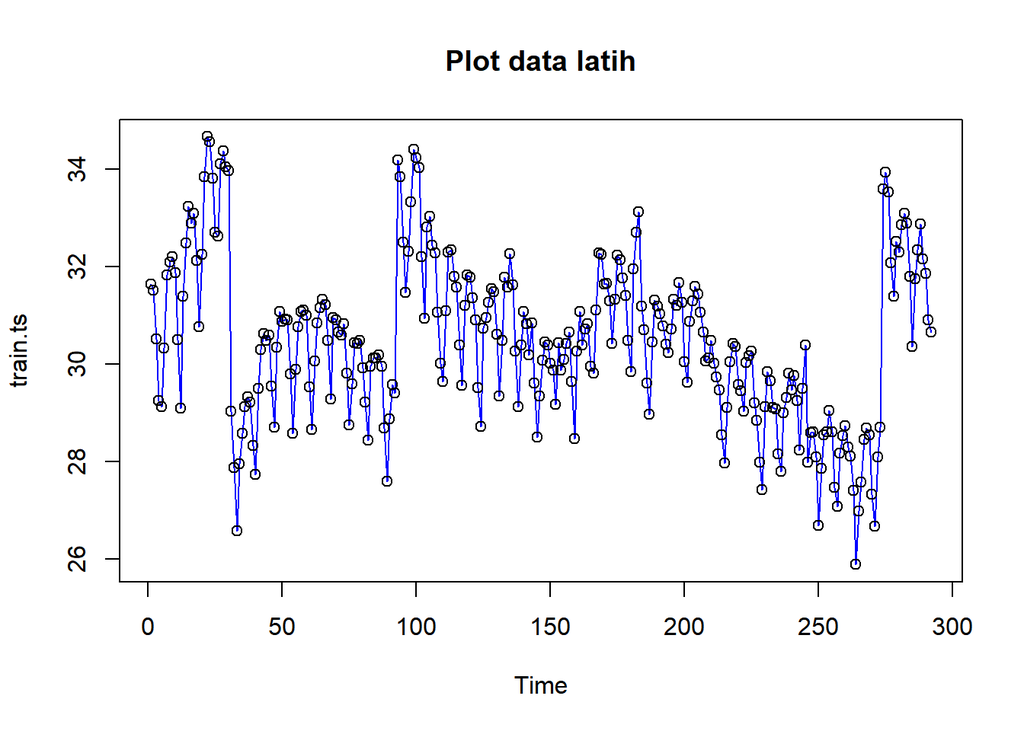

```r
#eksplorasi data latih
plot(train.ts, col="blue",main="Plot data latih")
points(train.ts)
```

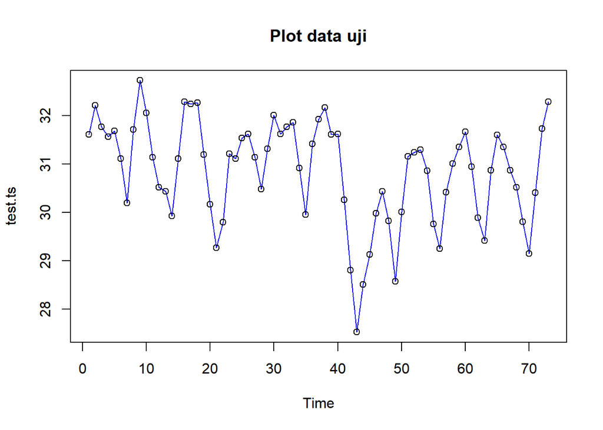

```r
#eksplorasi data uji
plot(test.ts, col="blue",main="Plot data uji")
points(test.ts)
```

### SMA

```r
data.sma<-SMA(train.ts, n=12)
data.sma
```

```
## Time Series:
## Start = 1
## End = 292
## Frequency = 1
##   [1]       NA       NA       NA       NA       NA       NA       NA       NA
##   [9]       NA       NA       NA 30.83417 30.81409 30.89443 31.12098 31.42478
##  [17] 31.75445 31.90400 31.81573 31.82792 31.96441 32.19653 32.53560 32.92861
##  [25] 33.03743 33.04918 33.12206 33.24518 33.32562 33.47977 33.33506 32.97114
##  [33] 32.36531 31.80636 31.30807 30.91825 30.63659 30.35218 29.87054 29.31673
##  [41] 28.93683 28.62995 28.76183 28.97873 29.31358 29.44630 29.45608 29.55668
##  [49] 29.70359 29.84223 30.05826 30.32256 30.34755 30.20510 30.14428 30.16865
##  [57] 30.20918 30.33899 30.53120 30.46430 30.26135 30.19371 30.18698 30.20863
##  [65] 30.33605 30.55612 30.60521 30.48056 30.47025 30.45283 30.42333 30.51176
##  [73] 30.69378 30.67282 30.49857 30.36767 30.29422 30.22673 30.22685 30.28017
##  [81] 30.13571 29.93055 29.87271 29.83413 29.77475 29.80543 29.90483 29.82986
```

[output cut: 26 more lines]

```r
data.ramal<-c(NA,data.sma)
data.ramal #forecast 1 periode ke depan
```

```
##   [1]       NA       NA       NA       NA       NA       NA       NA       NA
##   [9]       NA       NA       NA       NA 30.83417 30.81409 30.89443 31.12098
##  [17] 31.42478 31.75445 31.90400 31.81573 31.82792 31.96441 32.19653 32.53560
##  [25] 32.92861 33.03743 33.04918 33.12206 33.24518 33.32562 33.47977 33.33506
##  [33] 32.97114 32.36531 31.80636 31.30807 30.91825 30.63659 30.35218 29.87054
##  [41] 29.31673 28.93683 28.62995 28.76183 28.97873 29.31358 29.44630 29.45608
##  [49] 29.55668 29.70359 29.84223 30.05826 30.32256 30.34755 30.20510 30.14428
##  [57] 30.16865 30.20918 30.33899 30.53120 30.46430 30.26135 30.19371 30.18698
##  [65] 30.20863 30.33605 30.55612 30.60521 30.48056 30.47025 30.45283 30.42333
##  [73] 30.51176 30.69378 30.67282 30.49857 30.36767 30.29422 30.22673 30.22685
##  [81] 30.28017 30.13571 29.93055 29.87271 29.83413 29.77475 29.80543 29.90483
##  [89] 29.82986 29.59190 29.46403 29.38832 29.34530 29.75892 30.20942 30.42172
##  [97] 30.53318 30.71598 30.97857 31.35066 31.81274 32.34964 32.62607 32.74025
## [105] 33.02516 32.92908 32.81139 32.79248 32.75911 32.56701 32.25947 31.98302
## [113] 31.82123 31.68107 31.64755 31.70024 31.49737 31.20830 31.10535 31.06827
```

[output cut: 22 more lines]

Selanjutnya akan dilakukan peramalan sejumlah data uji yaitu 73 periode. Pada metode SMA, hasil peramalan 73 periode ke depan akan bernilai sama dengan hasil peramalan 1 periode kedepan. Dalam hal ini akan dilakukan pengguabungan data aktual train, data hasil pemulusan dan data hasil ramalan 73 periode kedepan.

```r
data.gab<-cbind(aktual=c(train.ts,rep(NA,73)),pemulusan=c(data.sma,rep(NA,73)),ramalan=c(data.ramal,rep(data.ramal[length(data.ramal)],72)))
data.gab #forecast 73 periode ke depan
```

```
##         aktual pemulusan  ramalan
##   [1,] 31.6386        NA       NA
##   [2,] 31.5217        NA       NA
##   [3,] 30.5202        NA       NA
##   [4,] 29.2529        NA       NA
##   [5,] 29.1330        NA       NA
##   [6,] 30.3331        NA       NA
##   [7,] 31.8336        NA       NA
##   [8,] 32.0991        NA       NA
##   [9,] 32.2085        NA       NA
##  [10,] 31.8824        NA       NA
##  [11,] 30.4946        NA       NA
##  [12,] 29.0924  30.83417       NA
##  [13,] 31.3976  30.81409 30.83417
##  [14,] 32.4858  30.89443 30.81409
```

[output cut: 351 more lines]

Adapun plot data deret waktu dari hasil peramalan yang dilakukan adalah sebagai berikut.

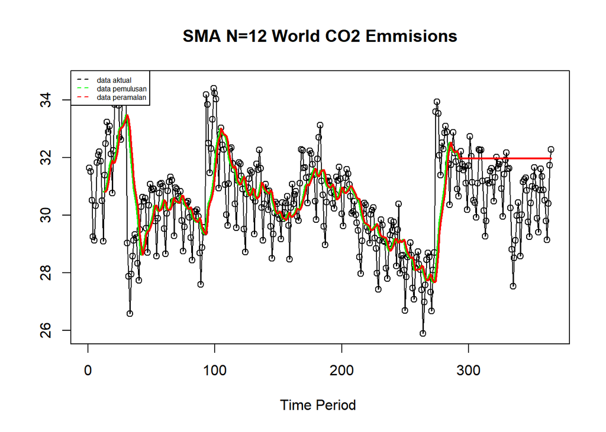

```r
ts.plot(data1.ts, xlab="Time Period ", ylab="", main= "SMA N=12 World CO2 Emmisions")
points(data1.ts)
lines(data.gab[,2],col="green",lwd=2)
lines(data.gab[,3],col="red",lwd=2)
legend("topleft",c("data aktual","data pemulusan","data peramalan"), lty=8, col=c("black","green","red"), cex=0.5)
```

Selanjutnya perhitungan akurasi dilakukan dengan ukuran akurasi *Sum Squares Error* (SSE), *Mean Square Error* (MSE) dan *Mean Absolute Percentage Error* (MAPE). Perhitungan akurasi dilakukan baik pada data latih maupun pada data uji.

```r
#Menghitung nilai keakuratan data latih
error_train.sma = train.ts-data.ramal[1:length(train.ts)]
SSE_train.sma = sum(error_train.sma[13:length(train.ts)]^2)
MSE_train.sma = mean(error_train.sma[13:length(train.ts)]^2)
MAPE_train.sma = mean(abs((error_train.sma[13:length(train.ts)]/train.ts[13:length(train.ts)])*100))

akurasi_train.sma <- matrix(c(SSE_train.sma, MSE_train.sma, MAPE_train.sma))
row.names(akurasi_train.sma)<- c("SSE", "MSE", "MAPE")
colnames(akurasi_train.sma) <- c("Akurasi m = 12")
akurasi_train.sma
```

```
##      Akurasi m = 12
## SSE      613.634246
## MSE        2.191551
## MAPE       3.452927
```

Perhitungan akurasi menggunakan data latih menghasilkan nilai MAPE yang kurang dari 10% sehingga nilai akurasi ini dapat dikategorikan sebagai sangat baik, tetapi memiliki nilai SSE cukup besar.

```r
#Menghitung nilai keakuratan data uji
error_test.sma = test.ts-data.gab[293:365,3]
SSE_test.sma = sum(error_test.sma^2)
MSE_test.sma = mean(error_test.sma^2)
MAPE_test.sma = mean(abs((error_test.sma/test.ts*100)))

akurasi_test.sma <- matrix(c(SSE_test.sma, MSE_test.sma, MAPE_test.sma))
row.names(akurasi_test.sma)<- c("SSE", "MSE", "MAPE")
colnames(akurasi_test.sma) <- c("Akurasi m = 12")
akurasi_test.sma
```

```
##      Akurasi m = 12
## SSE      171.674151
## MSE        2.351701
## MAPE       3.953149
```

Begitujuga dengan data uji memiliki nilai MAPE < 10%. Selanjutnya dilakukan perbandingan dengan pemilihan m = 3

```r
data.sma2<-SMA(train.ts, n=3)
```

```r
data.ramal2<-c(NA,data.sma2) #forecast 1 periode ke depan
```

Selanjutnya akan dilakukan peramalan sejumlah data uji yaitu 73 periode. Pada metode SMA, hasil peramalan 73 periode ke depan akan bernilai sama dengan hasil peramalan 1 periode kedepan. Dalam hal ini akan dilakukan pengguabungan data aktual train, data hasil pemulusan dan data hasil ramalan 73 periode kedepan.

```r
data.gab2<-cbind(aktual=c(train.ts,rep(NA,73)),pemulusan=c(data.sma2,rep(NA,73)),ramalan=c(data.ramal2,rep(data.ramal[length(data.ramal2)],72))) #forecast 24 periode ke depan
```

Adapun plot data deret waktu dari hasil peramalan yang dilakukan adalah sebagai berikut.

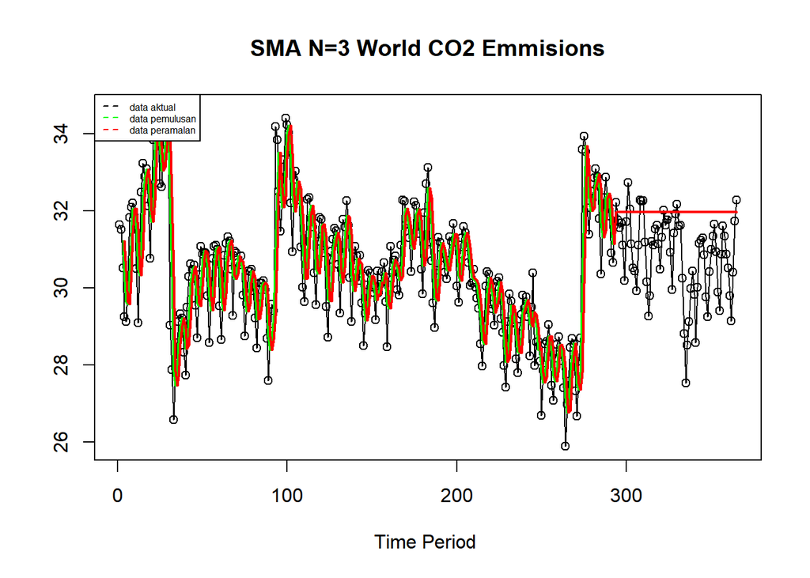

```r
ts.plot(data1.ts, xlab="Time Period ", ylab="", main= "SMA N=3 World CO2 Emmisions")
points(data1.ts)
lines(data.gab2[,2],col="green",lwd=2)
lines(data.gab2[,3],col="red",lwd=2)
legend("topleft",c("data aktual","data pemulusan","data peramalan"), lty=8, col=c("black","green","red"), cex=0.5)
```

```r
#Menghitung nilai keakuratan data latih
error_train.sma2 = train.ts-data.ramal2[1:length(train.ts)]
SSE_train.sma2 = sum(error_train.sma2[4:length(train.ts)]^2)
MSE_train.sma2 = mean(error_train.sma2[4:length(train.ts)]^2)
MAPE_train.sma2 = mean(abs((error_train.sma2[4:length(train.ts)]/train.ts[4:length(train.ts)])*100))

akurasi_train.sma2 <- matrix(c(SSE_train.sma2, MSE_train.sma2, MAPE_train.sma2))
row.names(akurasi_train.sma2)<- c("SSE", "MSE", "MAPE")
colnames(akurasi_train.sma2) <- c("Akurasi m = 3")
akurasi_train.sma2
```

```
##      Akurasi m = 3
## SSE     481.045051
## MSE       1.664516
## MAPE      3.310990
```

```r
#Menghitung nilai keakuratan data uji
error_test.sma2 = test.ts-data.gab2[293:365,3]
SSE_test.sma2 = sum(error_test.sma2^2)
MSE_test.sma2 = mean(error_test.sma2^2)
MAPE_test.sma2 = mean(abs((error_test.sma2/test.ts*100)))

akurasi_test.sma2 <- matrix(c(SSE_test.sma2, MSE_test.sma2, MAPE_test.sma2))
row.names(akurasi_test.sma2)<- c("SSE", "MSE", "MAPE")
colnames(akurasi_test.sma2) <- c("Akurasi m = 12")
akurasi_test.sma2
```

```
##      Akurasi m = 12
## SSE      171.766726
## MSE        2.352969
## MAPE       3.958023
```

Berikut adalah perbandingan SMA dengan m = 12 dan m =3

```r
# Membuat tabel komparasi
komparasi <- data.frame(
  Model = c("SMA (m = 12) - Data Latih", "SMA (m = 12) - Data Uji", "SMA (m = 3) - Data Latih", "SMA (m = 3) - Data Uji"),
  SSE = c(SSE_train.sma, SSE_test.sma, SSE_train.sma2, SSE_test.sma2),
  MSE = c(MSE_train.sma, MSE_test.sma, MSE_train.sma2, MSE_test.sma2),
  MAPE = c(MAPE_train.sma, MAPE_test.sma, MAPE_train.sma2, MAPE_test.sma2)
)

# Tampilkan tabel komparasi
print(komparasi)
```

```
##                       Model      SSE      MSE     MAPE
## 1 SMA (m = 12) - Data Latih 613.6342 2.191551 3.452927
## 2   SMA (m = 12) - Data Uji 171.6742 2.351701 3.953149
## 3  SMA (m = 3) - Data Latih 481.0451 1.664516 3.310990
## 4    SMA (m = 3) - Data Uji 171.7667 2.352969 3.958023
```

### DMA

Metode pemulusan Double Moving Average (DMA) pada dasarnya mirip dengan SMA. Namun demikian, metode ini lebih cocok digunakan untuk pola data trend. Proses pemulusan dengan rata rata dalam metode ini dilakukan sebanyak 2 kali.

Parameter m = 3

```r
dma <- SMA(data.sma2, n = 3)
At <- 2*data.sma2 - dma
Bt <- 2/(3-1)*(data.sma2 - dma)
data.dma<- At+Bt
data.ramal2<- c(NA, data.dma)

t = 1:73
f = c()

for (i in t) {
  f[i] = At[length(At)] + Bt[length(Bt)]*(i)
}

data.gab2 <- cbind(aktual = c(train.ts,rep(NA,73)), pemulusan1 = c(data.sma,rep(NA,73)),pemulusan2 = c(data.dma, rep(NA,73)),At = c(At, rep(NA,73)), Bt = c(Bt,rep(NA,73)),ramalan = c(data.ramal2, f[-1]))
data.gab2
```

```
##         aktual pemulusan1 pemulusan2       At           Bt    ramalan
##   [1,] 31.6386         NA         NA       NA           NA         NA
##   [2,] 31.5217         NA         NA       NA           NA         NA
##   [3,] 30.5202         NA         NA       NA           NA         NA
##   [4,] 29.2529         NA         NA       NA           NA         NA
##   [5,] 29.1330         NA   28.04357 28.83947 -0.795900000         NA
##   [6,] 30.3331         NA   28.95902 29.26601 -0.306988889 28.0435667
##   [7,] 31.8336         NA   31.53863 30.98593  0.552700000 28.9590222
##   [8,] 32.0991         NA   33.31369 32.36781  0.945877778 31.5386333
##   [9,] 32.2085         NA   33.53971 32.79339  0.746322222 33.3136889
##  [10,] 31.8824         NA   32.50178 32.28256  0.219222222 33.5397111
##  [11,] 30.4946         NA   30.82623 31.17737 -0.351133333 32.5017778
##  [12,] 29.0924   30.83417   28.74831 29.61906 -0.870744444 30.8262333
##  [13,] 31.3976   30.81409   29.42027 29.87423 -0.453966667 28.7483111
##  [14,] 32.4858   30.89443   31.76918 31.38056  0.388622222 29.4202667
```

[output cut: 351 more lines]

Hasil pemulusan menggunakan metode DMA divisualisasikan sebagai berikut

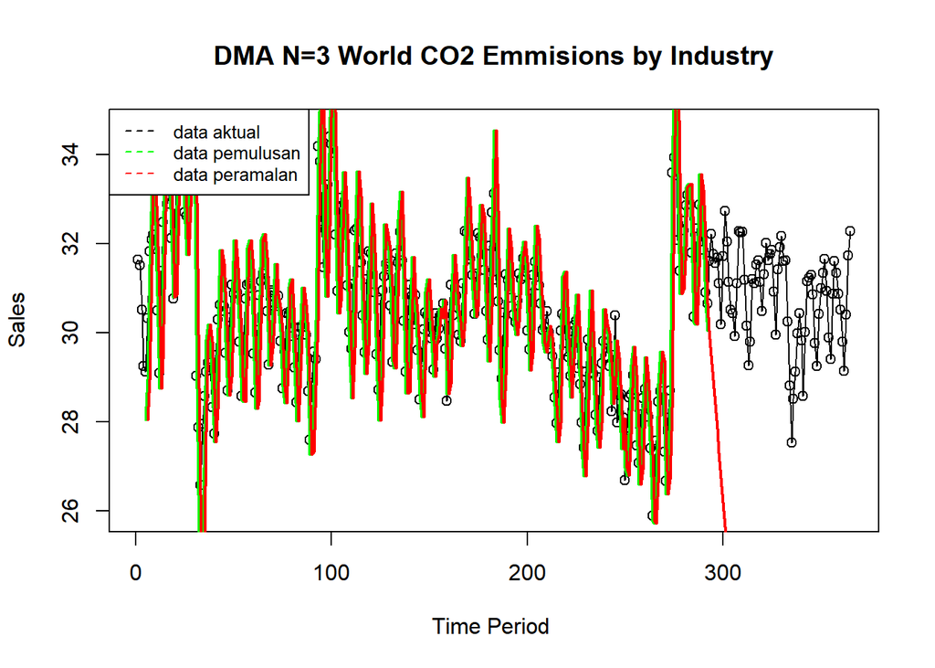

```r
ts.plot(data1.ts, xlab="Time Period ", ylab="Sales", main= "DMA N=3 World CO2 Emmisions by Industry")
points(data1.ts)
lines(data.gab2[,3],col="green",lwd=2)
lines(data.gab2[,6],col="red",lwd=2)
legend("topleft",c("data aktual","data pemulusan","data peramalan"), lty=8, col=c("black","green","red"), cex=0.8)
```

```r
#Menghitung nilai keakuratan data latih
error_train.dma = train.ts-data.ramal2[1:length(train.ts)]
SSE_train.dma = sum(error_train.dma[6:length(train.ts)]^2)
MSE_train.dma = mean(error_train.dma[6:length(train.ts)]^2)
MAPE_train.dma = mean(abs((error_train.dma[6:length(train.ts)]/train.ts[6:length(train.ts)])*100))

akurasi_train.dma <- matrix(c(SSE_train.dma, MSE_train.dma, MAPE_train.dma))
row.names(akurasi_train.dma)<- c("SSE", "MSE", "MAPE")
colnames(akurasi_train.dma) <- c("Akurasi m = 3")
akurasi_train.dma
```

```
##      Akurasi m = 3
## SSE     708.643456
## MSE       2.469141
## MAPE      4.244531
```

Model ini memiliki MAPE < 10%. Oleh karena itu, model ini masih tergolong baik.

```r
#Menghitung nilai keakuratan data uji
error_test.dma = test.ts-data.gab2[293:365,6]
SSE_test.dma = sum(error_test.dma^2)
MSE_test.dma = mean(error_test.dma^2)
MAPE_test.dma = mean(abs((error_test.dma/test.ts*100)))

akurasi_test.dma <- matrix(c(SSE_test.dma, MSE_test.dma, MAPE_test.dma))
row.names(akurasi_test.dma)<- c("SSE", "MSE", "MAPE")
colnames(akurasi_test.dma) <- c("Akurasi m = 3")
akurasi_test.dma
```

```
##      Akurasi m = 3
## SSE     40405.2215
## MSE       553.4962
## MAPE       67.2072
```

Model ini memiliki MAPE tidak kurang dari 10%. Nilai ini terbilang cukup tinggi dan tergolong model yang kurang baik

Parameter m = 12

```r
dma <- SMA(data.sma, n = 12)
At <- 2*data.sma - dma
Bt <- 2/(12-1)*(data.sma - dma)
data.dma<- At+Bt
data.ramal2<- c(NA, data.dma)

t = 1:73
f = c()

for (i in t) {
  f[i] = At[length(At)] + Bt[length(Bt)]*(i)
}

data.gab3 <- cbind(aktual = c(train.ts,rep(NA,73)), pemulusan1 = c(data.sma,rep(NA,73)),pemulusan2 = c(data.dma, rep(NA,73)),At = c(At, rep(NA,73)), Bt = c(Bt,rep(NA,73)),ramalan = c(data.ramal2, f[-1]))
data.gab3
```

```
##         aktual pemulusan1 pemulusan2       At            Bt  ramalan
##   [1,] 31.6386         NA         NA       NA            NA       NA
##   [2,] 31.5217         NA         NA       NA            NA       NA
##   [3,] 30.5202         NA         NA       NA            NA       NA
##   [4,] 29.2529         NA         NA       NA            NA       NA
##   [5,] 29.1330         NA         NA       NA            NA       NA
##   [6,] 30.3331         NA         NA       NA            NA       NA
##   [7,] 31.8336         NA         NA       NA            NA       NA
##   [8,] 32.0991         NA         NA       NA            NA       NA
##   [9,] 32.2085         NA         NA       NA            NA       NA
##  [10,] 31.8824         NA         NA       NA            NA       NA
##  [11,] 30.4946         NA         NA       NA            NA       NA
##  [12,] 29.0924   30.83417         NA       NA            NA       NA
##  [13,] 31.3976   30.81409         NA       NA            NA       NA
##  [14,] 32.4858   30.89443         NA       NA            NA       NA
```

[output cut: 351 more lines]

Hasil pemulusan menggunakan metode DMA divisualisasikan sebagai berikut

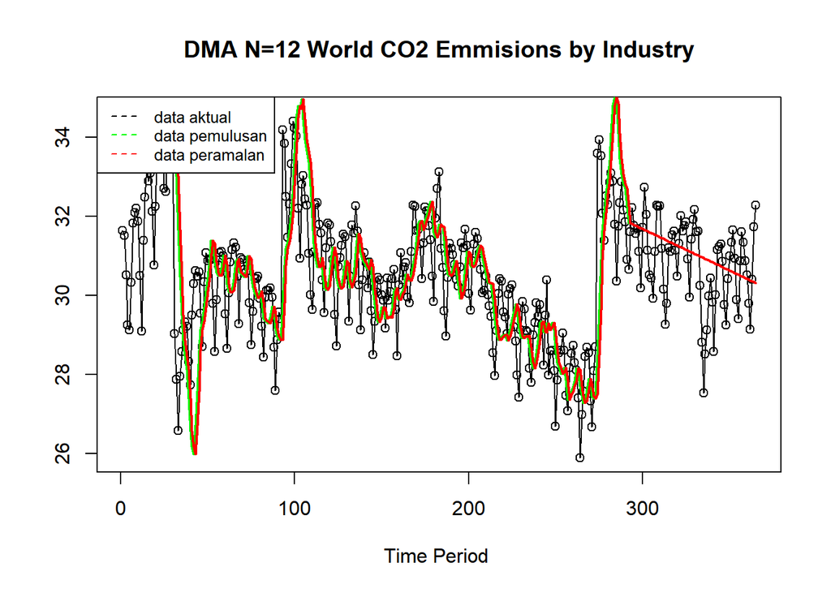

```r
ts.plot(data1.ts, xlab="Time Period ", ylab="", main= "DMA N=12 World CO2 Emmisions by Industry")
points(data1.ts)
lines(data.gab3[,3],col="green",lwd=2)
lines(data.gab3[,6],col="red",lwd=2)
legend("topleft",c("data aktual","data pemulusan","data peramalan"), lty=8, col=c("black","green","red"), cex=0.8)
```

```r
#Menghitung nilai keakuratan data latih
error_train.dma2 = train.ts-data.ramal[1:length(train.ts)]
SSE_train.dma2 = sum(error_train.dma2[24:length(train.ts)]^2)
MSE_train.dma2 = mean(error_train.dma2[24:length(train.ts)]^2)
MAPE_train.dma2 = mean(abs((error_train.dma2[24:length(train.ts)]/train.ts[24:length(train.ts)])*100))

akurasi_train.dma2 <- matrix(c(SSE_train.dma2, MSE_train.dma2, MAPE_train.dma2))
row.names(akurasi_train.dma2)<- c("SSE", "MSE", "MAPE")
colnames(akurasi_train.dma2) <- c("Akurasi m = 12")
akurasi_train.dma2
```

```
##      Akurasi m = 12
## SSE      580.511594
## MSE        2.158036
## MAPE       3.403786
```

Nilai MAPE < 10. Model ini tergolong baik

```r
#Menghitung nilai keakuratan data uji
error_test.dma2 = test.ts-data.gab3[293:365,6]
SSE_test.dma2 = sum(error_test.dma2^2)
MSE_test.dma2 = mean(error_test.dma2^2)
MAPE_test.dma2 = mean(abs((error_test.dma2/test.ts*100)))

akurasi_test.dma2 <- matrix(c(SSE_test.dma2, MSE_test.dma2, MAPE_test.dma2))
row.names(akurasi_test.dma2)<- c("SSE", "MSE", "MAPE")
colnames(akurasi_test.dma2) <- c("Akurasi m = 12")
akurasi_test.dma2
```

```
##      Akurasi m = 12
## SSE       78.060403
## MSE        1.069321
## MAPE       2.656738
```

Nilai MAPE < 10. Model ini tergolong baik

```r
# Membuat tabel komparasi DMA
komparasi_dma <- data.frame(
  Model = c("DMA (m = 12) - Data Latih (Model 1)", "DMA (m = 12) - Data Uji (Model 1)", "DMA (m = 3) - Data Latih (Model 2)", "DMA (m = 3) - Data Uji (Model 2)"),
  SSE = c(SSE_train.dma2, SSE_test.dma2, SSE_train.dma, SSE_test.dma),
  MSE = c(MSE_train.dma2, MSE_test.dma2, MSE_train.dma, MSE_test.dma),
  MAPE = c(MAPE_train.dma2, MAPE_test.dma2, MAPE_train.dma, MAPE_test.dma)
)

# Tampilkan tabel komparasi DMA
print(komparasi_dma)
```

```
##                                 Model        SSE        MSE      MAPE
## 1 DMA (m = 12) - Data Latih (Model 1)   580.5116   2.158036  3.403786
## 2   DMA (m = 12) - Data Uji (Model 1)    78.0604   1.069321  2.656738
## 3  DMA (m = 3) - Data Latih (Model 2)   708.6435   2.469141  4.244531
## 4    DMA (m = 3) - Data Uji (Model 2) 40405.2215 553.496185 67.207199
```

DMA dengan m = 12 lebih baik daripada m = 3.

###Perbandingan SMA dan DMA

```r
# Membuat tabel komparasi SMA dan DMA
# Data latih untuk SMA dan DMA
data_train_sma <- data.frame(
  Model = c("SMA (m = 12) - Data Latih", "SMA (m = 3) - Data Latih"),
  SSE = c(SSE_train.sma, SSE_train.sma2),
  MSE = c(MSE_train.sma, MSE_train.sma2),
  MAPE = c(MAPE_train.sma, MAPE_train.sma2),
  Data = "Data Latih"
)

data_train_dma <- data.frame(
  Model = c("DMA (m = 12) - Data Latih", "DMA (m = 3) - Data Latih"),
  SSE = c(SSE_train.dma, SSE_train.dma2),
  MSE = c(MSE_train.dma, MSE_train.dma2),
  MAPE = c(MAPE_train.dma, MAPE_train.dma2),
  Data = "Data Latih"
)

# Data uji untuk SMA dan DMA
data_test_sma <- data.frame(
  Model = c("SMA (m = 12) - Data Uji", "SMA (m = 3) - Data Uji"),
  SSE = c(SSE_test.sma, SSE_test.sma2),
  MSE = c(MSE_test.sma, MSE_test.sma2),
  MAPE = c(MAPE_test.sma, MAPE_test.sma2),
  Data = "Data Uji"
)

data_test_dma <- data.frame(
  Model = c("DMA (m = 12) - Data Uji", "DMA (m = 3) - Data Uji"),
  SSE = c(SSE_test.dma, SSE_test.dma2),
  MSE = c(MSE_test.dma, MSE_test.dma2),
  MAPE = c(MAPE_test.dma, MAPE_test.dma2),
  Data = "Data Uji"
)

# Gabungkan data latih dan data uji untuk SMA dan DMA
komparasi_sma_dma_latih <- rbind(data_train_sma, data_train_dma)

# Tampilkan tabel komparasi SMA dan DMA
print(komparasi_sma_dma_latih)
```

```
##                       Model      SSE      MSE     MAPE       Data
## 1 SMA (m = 12) - Data Latih 613.6342 2.191551 3.452927 Data Latih
## 2  SMA (m = 3) - Data Latih 481.0451 1.664516 3.310990 Data Latih
## 3 DMA (m = 12) - Data Latih 708.6435 2.469141 4.244531 Data Latih
## 4  DMA (m = 3) - Data Latih 580.5116 2.158036 3.403786 Data Latih
```

Menurut Data Latih, model SMA dengan m = 3 lebih unggul

```r
# Gabungkan data latih dan data uji untuk SMA dan DMA
komparasi_sma_dma_uji <- rbind(data_test_sma, data_test_dma)

# Tampilkan tabel komparasi SMA dan DMA
print(komparasi_sma_dma_uji)
```

```
##                     Model        SSE        MSE      MAPE     Data
## 1 SMA (m = 12) - Data Uji   171.6742   2.351701  3.953149 Data Uji
## 2  SMA (m = 3) - Data Uji   171.7667   2.352969  3.958023 Data Uji
## 3 DMA (m = 12) - Data Uji 40405.2215 553.496185 67.207199 Data Uji
## 4  DMA (m = 3) - Data Uji    78.0604   1.069321  2.656738 Data Uji
```

## Single Exponential Smoothing & Double Exponential Smoothing

```r
#membagi training dan testing
training<-data[1:292,]
testing<-data[293:365,]
train.ts <- ts(training$value)
test.ts <- ts(testing$value)
```

###SES

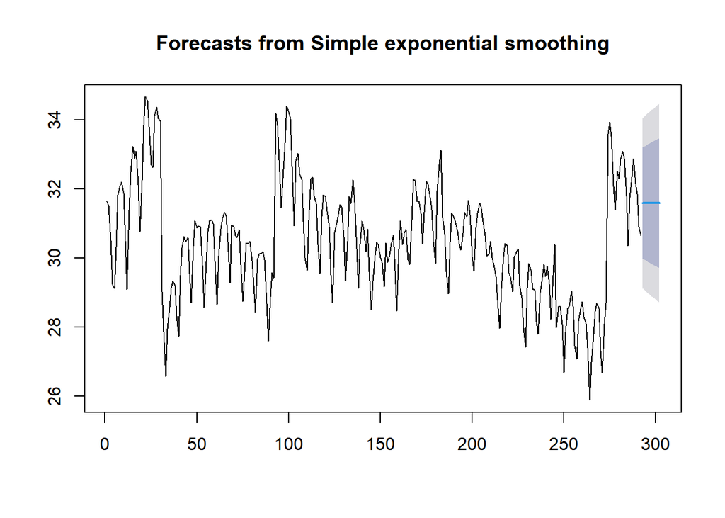

```r
#Cara 1 (fungsi ses)
ses.1 <- ses(train.ts, h = 10, alpha = 0.2)
plot(ses.1)
```

```r
ses.1
```

```
##     Point Forecast    Lo 80    Hi 80    Lo 95    Hi 95
## 293        31.5954 29.98490 33.20591 29.13234 34.05846
## 294        31.5954 29.95300 33.23781 29.08357 34.10724
## 295        31.5954 29.92171 33.26909 29.03572 34.15509
## 296        31.5954 29.89100 33.29981 28.98875 34.20206
## 297        31.5954 29.86083 33.32998 28.94261 34.24820
## 298        31.5954 29.83118 33.35963 28.89726 34.29355
## 299        31.5954 29.80202 33.38879 28.85266 34.33815
## 300        31.5954 29.77332 33.41749 28.80877 34.38204
## 301        31.5954 29.74507 33.44574 28.76556 34.42525
## 302        31.5954 29.71724 33.47356 28.72301 34.46780
```

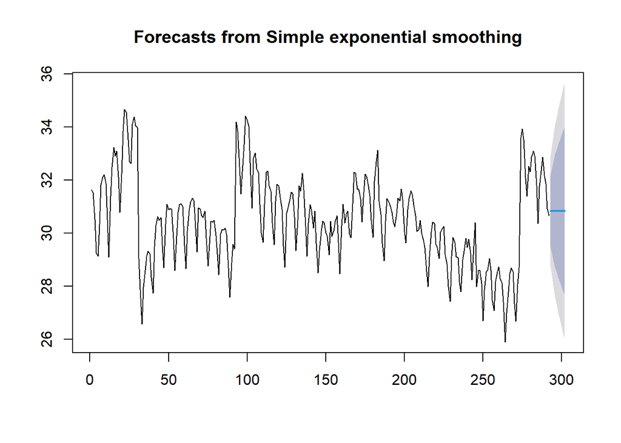

```r
ses.2<- ses(train.ts, h = 10, alpha = 0.7)
plot(ses.2)
```

```r
ses.2
```

```
##     Point Forecast    Lo 80    Hi 80    Lo 95    Hi 95
## 293       30.83466 29.47712 32.19221 28.75847 32.91086
## 294       30.83466 29.17757 32.49176 28.30035 33.36898
## 295       30.83466 28.92442 32.74490 27.91320 33.75612
## 296       30.83466 28.70111 32.96822 27.57167 34.09766
## 297       30.83466 28.49905 33.17028 27.26265 34.40668
## 298       30.83466 28.31313 33.35620 26.97831 34.69102
## 299       30.83466 28.14001 33.52932 26.71354 34.95579
## 300       30.83466 27.97736 33.69197 26.46479 35.20454
## 301       30.83466 27.82348 33.84585 26.22945 35.43988
## 302       30.83466 27.67709 33.99224 26.00557 35.66376
```

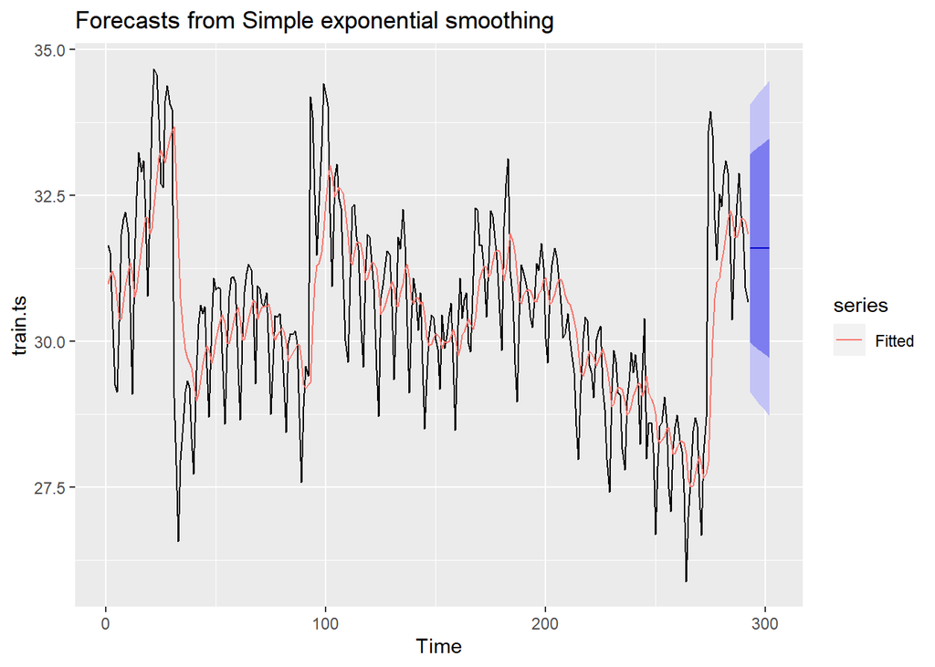

```r
autoplot(ses.1) +
  autolayer(fitted(ses.1), series="Fitted")
```

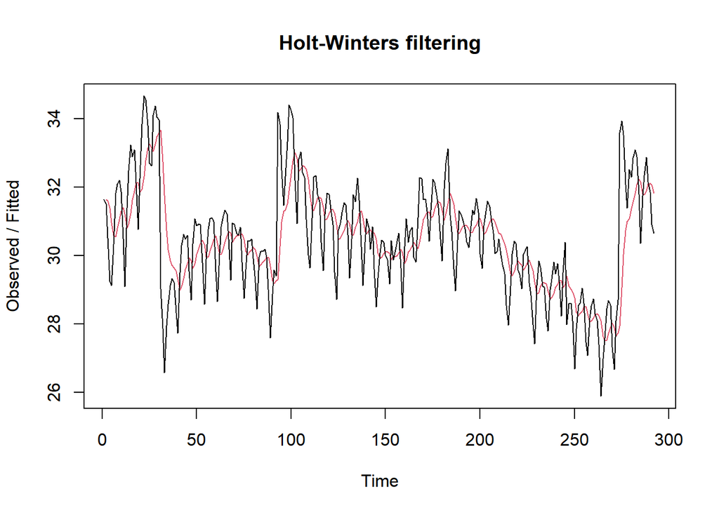

```r
#Cara 2 (fungsi Holtwinter)
ses1<- HoltWinters(train.ts, gamma = FALSE, beta = FALSE, alpha = 0.2)
plot(ses1)
```

```r
#ramalan
ramalan1<- forecast(ses1, h=73)
ramalan1
```

```
##     Point Forecast    Lo 80    Hi 80    Lo 95    Hi 95
## 293        31.5954 29.98282 33.20799 29.12917 34.06164
## 294        31.5954 29.95088 33.23992 29.08033 34.11048
## 295        31.5954 29.91956 33.27125 29.03242 34.15839
## 296        31.5954 29.88880 33.30200 28.98539 34.20542
## 297        31.5954 29.85860 33.33221 28.93919 34.25162
## 298        31.5954 29.82891 33.36190 28.89378 34.29703
## 299        31.5954 29.79971 33.39110 28.84912 34.34169
## 300        31.5954 29.77097 33.41984 28.80518 34.38563
## 301        31.5954 29.74268 33.44812 28.76191 34.42889
## 302        31.5954 29.71482 33.47599 28.71930 34.47150
## 303        31.5954 29.68737 33.50344 28.67731 34.51349
## 304        31.5954 29.66030 33.53051 28.63592 34.55489
## 305        31.5954 29.63361 33.55720 28.59510 34.59571
## 306        31.5954 29.60728 33.58353 28.55482 34.63598
```

[output cut: 59 more lines]

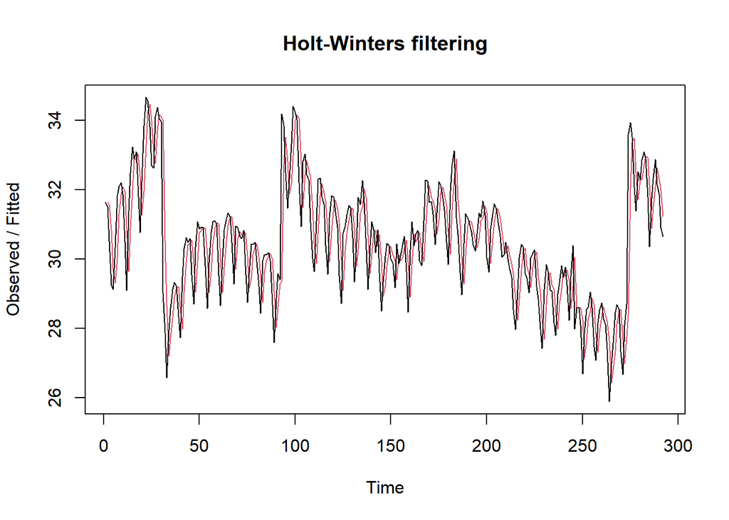

```r
ses2<- HoltWinters(train.ts, gamma = FALSE, beta = FALSE, alpha = 0.7)
plot(ses2)
```

```r
#ramalan
ramalan2<- forecast(ses2, h=73)
ramalan2
```

```
##     Point Forecast    Lo 80    Hi 80    Lo 95    Hi 95
## 293       30.83466 29.47707 32.19226 28.75840 32.91093
## 294       30.83466 29.17751 32.49182 28.30026 33.36907
## 295       30.83466 28.92436 32.74497 27.91310 33.75622
## 296       30.83466 28.70104 32.96829 27.57156 34.09777
## 297       30.83466 28.49897 33.17036 27.26253 34.40680
## 298       30.83466 28.31304 33.35629 26.97818 34.69115
## 299       30.83466 28.13991 33.52941 26.71340 34.95593
## 300       30.83466 27.97726 33.69207 26.46464 35.20469
## 301       30.83466 27.82337 33.84596 26.22929 35.44004
## 302       30.83466 27.67698 33.99235 26.00540 35.66393
## 303       30.83466 27.53708 34.13225 25.79144 35.87789
## 304       30.83466 27.40287 34.26645 25.58619 36.08313
## 305       30.83466 27.27373 34.39560 25.38868 36.28065
## 306       30.83466 27.14910 34.52023 25.19808 36.47125
```

[output cut: 59 more lines]

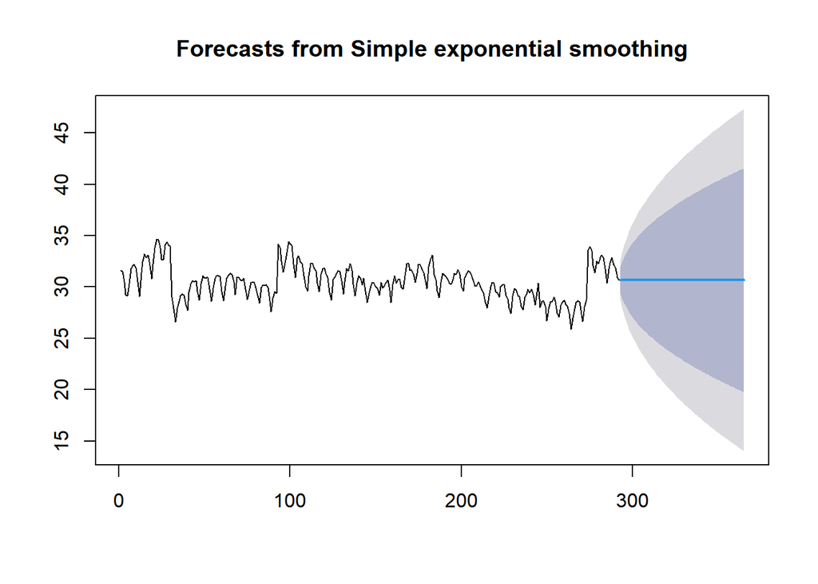

```r
#SES
ses.opt <- ses(train.ts, h = 73, alpha = NULL)
plot(ses.opt)
```

```r
ses.opt
```

```
##     Point Forecast    Lo 80    Hi 80    Lo 95    Hi 95
## 293       30.66273 29.38830 31.93715 28.71366 32.61179
## 294       30.66273 28.86050 32.46495 27.90647 33.41898
## 295       30.66273 28.45550 32.86995 27.28707 34.03838
## 296       30.66273 28.11406 33.21139 26.76488 34.56057
## 297       30.66273 27.81325 33.51220 26.30483 35.02062
## 298       30.66273 27.54129 33.78416 25.88890 35.43655
## 299       30.66273 27.29120 34.03425 25.50642 35.81903
## 300       30.66273 27.05842 34.26703 25.15041 36.17504
## 301       30.66273 26.83979 34.48566 24.81604 36.50941
## 302       30.66273 26.63300 34.69245 24.49979 36.82566
## 303       30.66273 26.43632 34.88913 24.19899 37.12646
## 304       30.66273 26.24839 35.07706 23.91158 37.41387
## 305       30.66273 26.06814 35.25731 23.63591 37.68954
## 306       30.66273 25.89470 35.43075 23.37066 37.95479
```

[output cut: 59 more lines]

```r
#Lamda Optimum Holt Winter
sesopt<- HoltWinters(train.ts, gamma = FALSE, beta = FALSE,alpha = NULL)
sesopt
```

```
## Holt-Winters exponential smoothing without trend and without seasonal component.
##
## Call:
## HoltWinters(x = train.ts, alpha = NULL, beta = FALSE, gamma = FALSE)
##
## Smoothing parameters:
##  alpha: 0.9999339
##  beta : FALSE
##  gamma: FALSE
##
## Coefficients:
##       [,1]
## a 30.66272
```

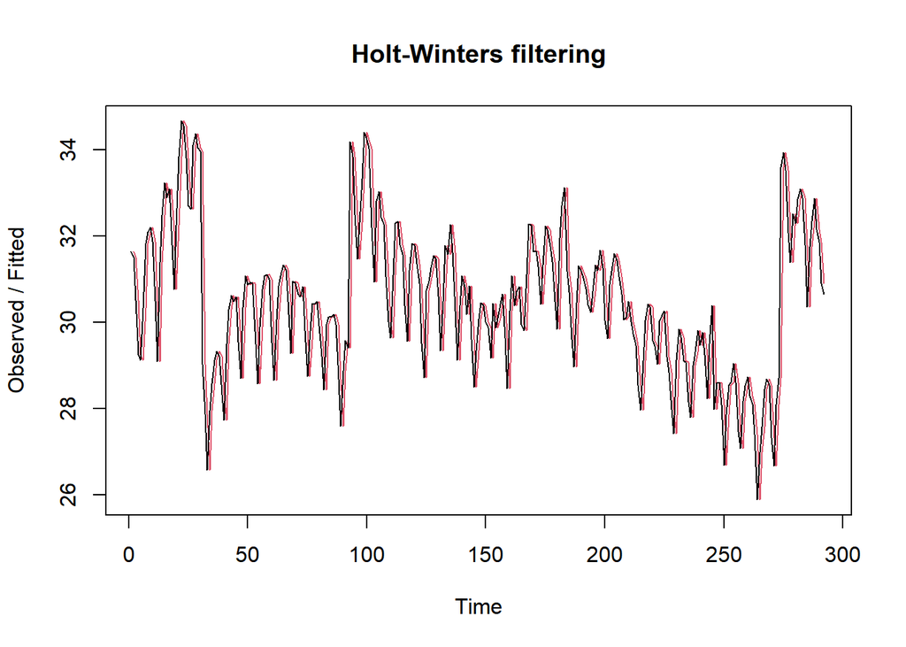

```r
plot(sesopt)
```

```r
#ramalan
ramalanopt<- forecast(sesopt, h=73)
ramalanopt
```

```
##     Point Forecast    Lo 80    Hi 80    Lo 95    Hi 95
## 293       30.66272 29.38830 31.93713 28.71367 32.61176
## 294       30.66272 28.86048 32.46495 27.90644 33.41899
## 295       30.66272 28.45547 32.86997 27.28702 34.03841
## 296       30.66272 28.11402 33.21142 26.76482 34.56061
## 297       30.66272 27.81319 33.51224 26.30475 35.02068
## 298       30.66272 27.54123 33.78420 25.88881 35.43662
## 299       30.66272 27.29113 34.03430 25.50632 35.81911
## 300       30.66272 27.05834 34.26709 25.15030 36.17513
## 301       30.66272 26.83970 34.48573 24.81592 36.50951
## 302       30.66272 26.63291 34.69252 24.49966 36.82577
## 303       30.66272 26.43622 34.88921 24.19885 37.12658
## 304       30.66272 26.24829 35.07714 23.91143 37.41400
## 305       30.66272 26.06804 35.25740 23.63576 37.68967
## 306       30.66272 25.89459 35.43084 23.37050 37.95493
```

[output cut: 59 more lines]

```r
#Keakuratan Metode
#Pada data training
#Cara 1 (fungsi ses)
actual <- train.ts
fitted1 <- fitted(ses.1)
MAPE1 <- 100*mean(abs((actual - fitted1) / actual))

fitted2 <- fitted(ses.2)
MAPE2 <- 100*mean(abs((actual - fitted2) / actual))

fittedopt <- fitted(ses.opt)
MAPEopt <- 100*mean(abs((actual - fitted2) / actual))

SSE1<-ses1$SSE
MSE1<-ses1$SSE/length(training)
RMSE1<-sqrt(MSE1)

akurasi1 <- matrix(c(SSE1,MSE1,RMSE1,MAPE1))
row.names(akurasi1)<- c("SSE", "MSE", "RMSE","MAPE")
colnames(akurasi1) <- c("Akurasi lamda=0.2")
akurasi1
```

```
##      Akurasi lamda=0.2
## SSE         459.167634
## MSE         229.583817
## RMSE         15.152024
## MAPE          3.002336
```

```r
SSE2<-ses2$SSE
MSE2<-ses2$SSE/length(training)
RMSE2<-sqrt(MSE2)

akurasi2 <- matrix(c(SSE2,MSE2,RMSE2,MAPE2))
row.names(akurasi2)<- c("SSE", "MSE", "RMSE", "MAPE")
colnames(akurasi2) <- c("Akurasi lamda=0.7")
akurasi2
```

```
##      Akurasi lamda=0.7
## SSE         325.441121
## MSE         162.720561
## RMSE         12.756197
## MAPE          2.711485
```

```r
SSEopt <- sesopt$SSE
MSEopt <- sesopt$SSE/length(training)
RMSEopt<-sqrt(MSEopt)

akurasi3 <- matrix(c(SSEopt,MSEopt,RMSEopt,MAPEopt))
row.names(akurasi3)<- c("SSE", "MSE", "RMSE", "MAPE")
colnames(akurasi3) <- c("Akurasi Optimum")
akurasi3
```

```
##      Akurasi Optimum
## SSE       286.781269
## MSE       143.390635
## RMSE       11.974583
## MAPE        2.711485
```

Akurasi Data Uji Akurasi data uji dapat dihitung dengan cara yang hampir sama dengan perhitungan akurasi data latih.

```r
selisih1<-ramalan1$mean - testing$value
SSEtesting1<-sum(selisih1^2)
MSEtesting1<-SSEtesting1/length(testing)

selisih2<-ramalan2$mean-testing$value
SSEtesting2<-sum(selisih2^2)
MSEtesting2<-SSEtesting2/length(testing)

selisihopt<-ramalanopt$mean-testing$value
SSEtestingopt<-sum(selisihopt^2)
MSEtestingopt<-SSEtestingopt/length(testing)

akurasitesting1 <- matrix(c(SSEtesting1,SSEtesting2,SSEtestingopt))
row.names(akurasitesting1)<- c("SSE1", "SSE2", "SSEopt")
akurasitesting1
```

```
##             [,1]
## SSE1   121.32947
## SSE2    81.12362
## SSEopt  83.74328
```

```r
akurasitesting2 <- matrix(c(MSEtesting1,MSEtesting2,MSEtestingopt))
row.names(akurasitesting2)<- c("MSE1", "MSE2", "MSEopt")
akurasitesting2
```

```
##            [,1]
## MSE1   60.66474
## MSE2   40.56181
## MSEopt 41.87164
```

```r
akurasi_comparison <- data.frame(
  Model = c("SES Lambda=0.2", "SES Lambda=0.7", "SES Optimum"),
  SSE = c(SSE1, SSE2, SSEopt),
  MSE = c(MSE1, MSE2, MSEopt),
  RMSE = c(RMSE1, RMSE2, RMSEopt),
  MAPE = c(MAPE1, MAPE2, MAPEopt)
)

# Tampilkan tabel
akurasi_comparison
```

```
##            Model      SSE      MSE     RMSE     MAPE
## 1 SES Lambda=0.2 459.1676 229.5838 15.15202 3.002336
## 2 SES Lambda=0.7 325.4411 162.7206 12.75620 2.711485
## 3    SES Optimum 286.7813 143.3906 11.97458 2.711485
```

Menurut Akurasi Data Uji, model SES dengan Lamda = 0.7 dan Optimum tergolong lebih baik daripada Model SES dengan Lamda = 0.2

###DES

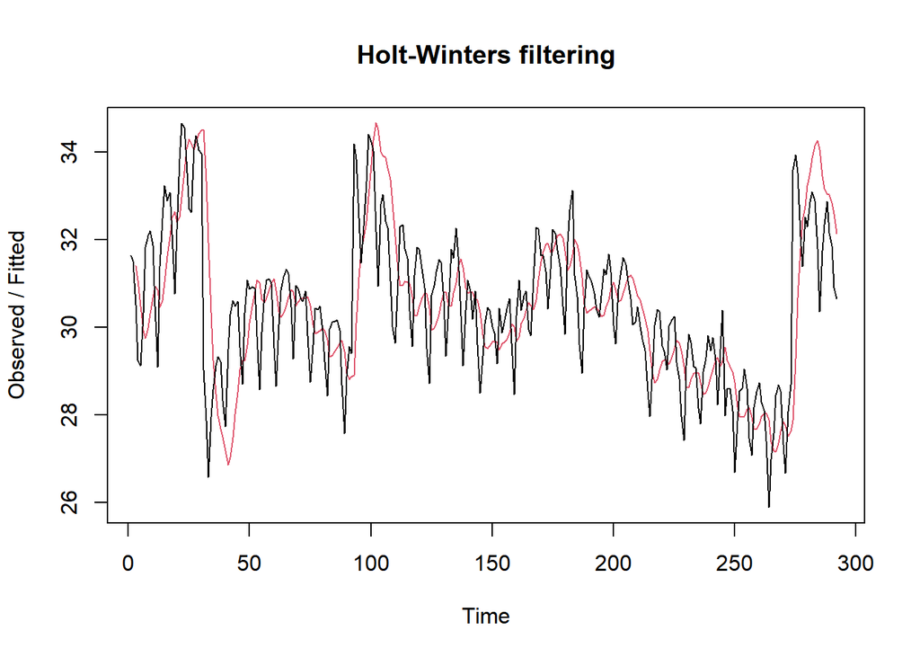

```r
#Lamda=0.2 dan gamma=0.2
des.1<- HoltWinters(train.ts, gamma = FALSE, beta = 0.2, alpha = 0.2)
plot(des.1)
```

```r
#ramalan
ramalandes1<- forecast(des.1, h=73)
ramalandes1
```

```
##     Point Forecast      Lo 80    Hi 80        Lo 95    Hi 95
## 293       31.67459 29.8840106 33.46516  28.93613705 34.41304
## 294       31.49774 29.6563221 33.33917  28.68153203 34.31396
## 295       31.32090 29.4124480 33.22936  28.40217311 34.23963
## 296       31.14406 29.1514470 33.13667  28.09662088 34.19150
## 297       30.96722 28.8729343 33.06150  27.76428693 34.17015
## 298       30.79038 28.5770055 33.00375  27.40531731 34.17544
## 299       30.61354 28.2641255 32.96295  27.02042297 34.20665
## 300       30.43669 27.9350089 32.93838  26.61069694 34.26269
## 301       30.25985 27.5905125 32.92919  26.17744955 34.34225
## 302       30.08301 27.2315499 32.93447  25.72207810 34.44394
## 303       29.90617 26.8590314 32.95331  25.24597459 34.56636
## 304       29.72933 26.4738255 32.98483  24.75046736 34.70819
## 305       29.55248 26.0767379 33.02823  24.23678869 34.86818
## 306       29.37564 25.6685025 33.08278  23.70606094 35.04522
```

[output cut: 59 more lines]

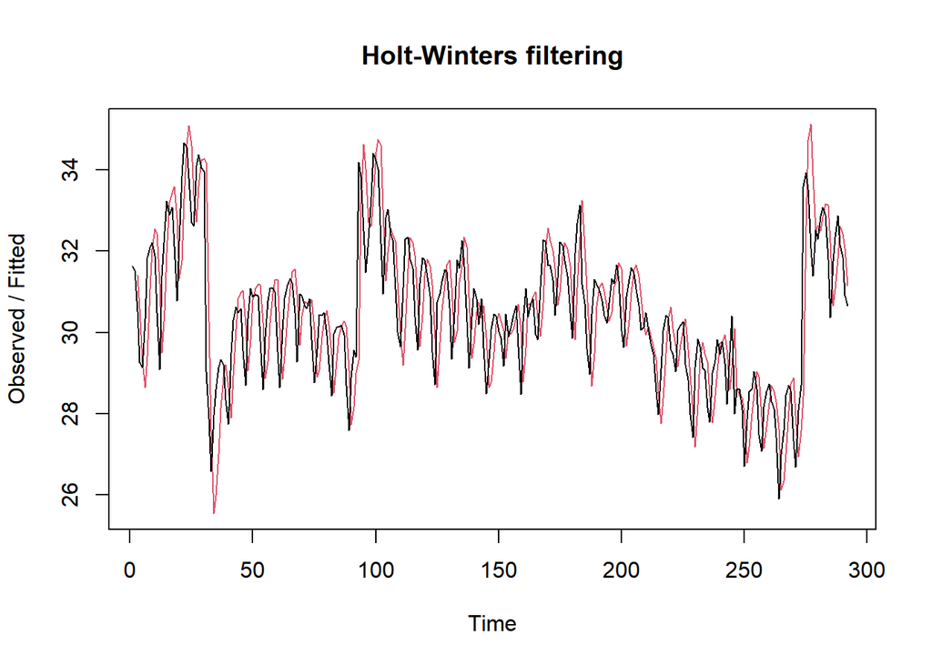

```r
#Lamda=0.6 dan gamma=0.3
des.2<- HoltWinters(train.ts, gamma = FALSE, beta = 0.3, alpha = 0.6)
plot(des.2)
```

```r
#ramalan
ramalandes2<- forecast(des.2, h=73)
ramalandes2
```

```
##     Point Forecast        Lo 80     Hi 80        Lo 95     Hi 95
## 293      30.545191   28.9559042  32.13448   28.1145866  32.97580
## 294      30.232534   28.2169576  32.24811   27.1499758  33.31509
## 295      29.919877   27.3919619  32.44779   26.0537643  33.78599
## 296      29.607221   26.4970874  32.71735   24.8506823  34.36376
## 297      29.294564   25.5430388  33.04609   23.5571015  35.03203
## 298      28.981907   24.5370152  33.42680   22.1840316  35.77978
## 299      28.669250   23.4840816  33.85442   20.7392192  36.59928
## 300      28.356593   22.3879801  34.32521   19.2283871  37.48480
## 301      28.043936   21.2515990  34.83627   17.6559527  38.43192
## 302      27.731280   20.0772505  35.38531   16.0254523  39.43711
## 303      27.418623   18.8668418  35.97040   14.3398025  40.49744
## 304      27.105966   17.6219842  36.58995   12.6014676  41.61046
## 305      26.793309   16.3440655  37.24255   10.8125701  42.77405
## 306      26.480652   15.0343001  37.92700    8.9749673  43.98634
```

[output cut: 59 more lines]

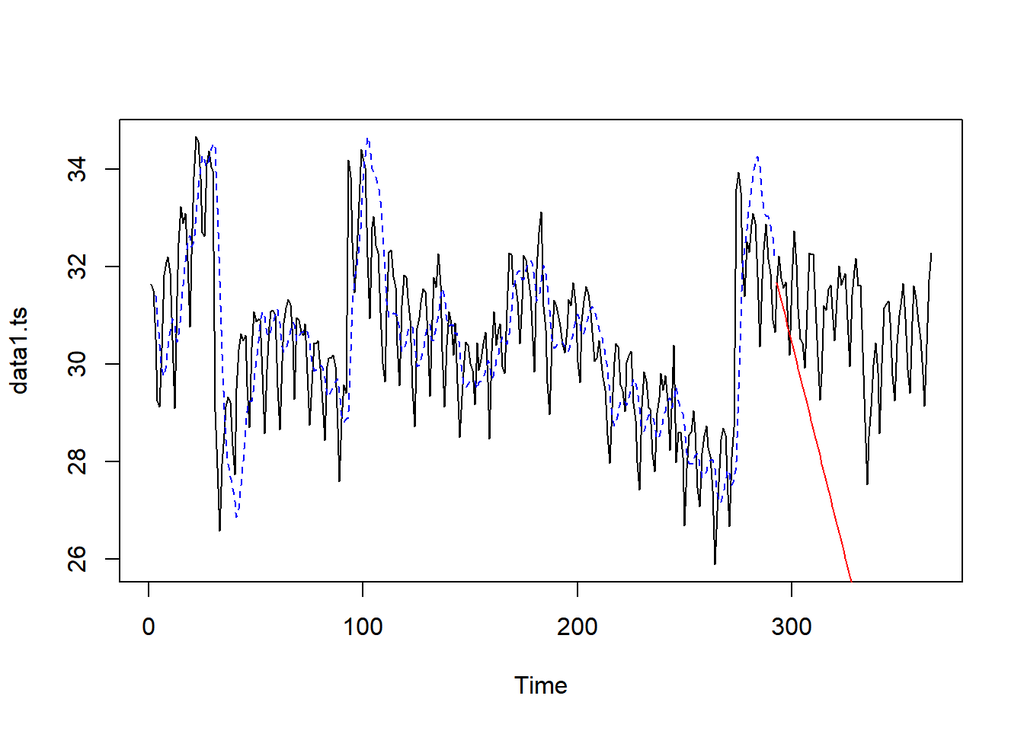

```r
#Visually evaluate the prediction
plot(data1.ts)
lines(des.1$fitted[,1], lty=2, col="blue")
lines(ramalandes1$mean, col="red")
```

```r
#Lamda dan gamma optimum
des.opt<- HoltWinters(train.ts, gamma = FALSE)
des.opt
```

```
## Holt-Winters exponential smoothing with trend and without seasonal component.
##
## Call:
## HoltWinters(x = train.ts, gamma = FALSE)
##
## Smoothing parameters:
##  alpha: 1
##  beta : 0.003977588
##  gamma: FALSE
##
## Coefficients:
##          [,1]
## a 30.66270000
## b -0.03696794
```

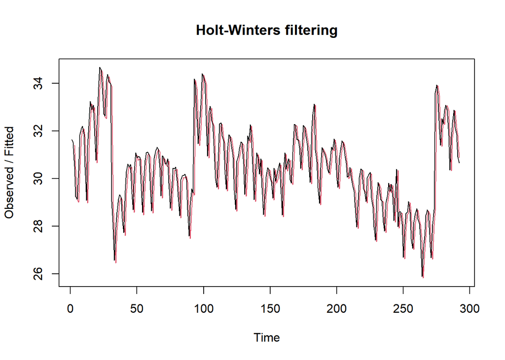

```r
plot(des.opt)
```

```r
#ramalan
ramalandesopt<- forecast(des.opt, h=73)
ramalandesopt
```

```
##     Point Forecast    Lo 80    Hi 80     Lo 95    Hi 95
## 293       30.62573 29.34652 31.90494 28.669351 32.58211
## 294       30.58876 28.77609 32.40144 27.816515 33.36101
## 295       30.55180 28.32732 32.77628 27.149748 33.95384
## 296       30.51483 27.94112 33.08854 26.578682 34.45097
## 297       30.47786 27.59466 33.36106 26.068389 34.88733
## 298       30.44089 27.27625 33.60553 25.600994 35.28079
## 299       30.40392 26.97896 33.82889 25.165899 35.64195
## 300       30.36696 26.69829 34.03562 24.756213 35.97770
## 301       30.32999 26.43110 34.22887 24.367160 36.29282
## 302       30.29302 26.17514 34.41090 23.995268 36.59077
## 303       30.25605 25.92869 34.58342 23.637922 36.87418
## 304       30.21908 25.69042 34.74775 23.293095 37.14507
## 305       30.18212 25.45929 34.90494 22.959178 37.40506
## 306       30.14515 25.23444 35.05586 22.634867 37.65543
```

[output cut: 59 more lines]

```r
#Akurasi Data Training
ssedes.train1<-des.1$SSE
msedes.train1<-ssedes.train1/length(train.ts)
sisaandes1<-ramalandes1$residuals
head(sisaandes1)
```

```
## Time Series:
## Start = 1
## End = 6
## Frequency = 1
## [1]         NA         NA -0.8846000 -1.8226960 -1.3528650  0.3971145
```

```r
mapedes.train1 <- sum(abs(sisaandes1[3:length(train.ts)]/train.ts[3:length(train.ts)])
                      *100)/length(train.ts)

akurasides.1 <- matrix(c(ssedes.train1,msedes.train1,mapedes.train1))
row.names(akurasides.1)<- c("SSE", "MSE", "MAPE")
colnames(akurasides.1) <- c("Akurasi lamda=0.2 dan gamma=0.2")
akurasides.1
```

```
##      Akurasi lamda=0.2 dan gamma=0.2
## SSE                        564.17912
## MSE                          1.93212
## MAPE                         3.39332
```

```r
ssedes.train2<-des.2$SSE
msedes.train2<-ssedes.train2/length(train.ts)
sisaandes2<-ramalandes2$residuals
head(sisaandes2)
```

```
## Time Series:
## Start = 1
## End = 6
## Frequency = 1
## [1]         NA         NA -0.8846000 -1.3450120 -0.1396746  1.6876017
```

```r
mapedes.train2 <- sum(abs(sisaandes2[3:length(train.ts)]/train.ts[3:length(train.ts)])
                      *100)/length(train.ts)

akurasides.2 <- matrix(c(ssedes.train2,msedes.train2,mapedes.train2))
row.names(akurasides.2)<- c("SSE", "MSE", "MAPE")
colnames(akurasides.2) <- c("Akurasi lamda=0.6 dan gamma=0.3")
akurasides.2
```

```
##      Akurasi lamda=0.6 dan gamma=0.3
## SSE                       444.461573
## MSE                         1.522129
## MAPE                        3.242870
```

```r
ssedes.trainopt<-des.opt$SSE
msedes.trainopt<-ssedes.trainopt/length(train.ts)
sisaandesopt<-ramalandesopt$residuals
head(sisaandesopt)
```

```
## Time Series:
## Start = 1
## End = 6
## Frequency = 1
## [1]           NA           NA -0.884600000 -1.146881426  0.005080396
## [6]  1.325060188
```

```r
mapedes.trainopt <- sum(abs(sisaandesopt[3:length(train.ts)]/train.ts[3:length(train.ts)])
                      *100)/length(train.ts)

akurasides.opt <- matrix(c(ssedes.trainopt,msedes.trainopt,mapedes.trainopt))
row.names(akurasides.opt)<- c("SSE", "MSE", "MAPE")
colnames(akurasides.opt) <- c("Akurasi Optimum")
akurasides.opt
```

```
##      Akurasi Optimum
## SSE      289.3369302
## MSE        0.9908799
## MAPE       2.4330603
```

```r
# Membuat data frame untuk komparasi akurasi
akurasi_komparasi <- data.frame(
  Model = c("Akurasi lamda=0.2 dan gamma=0.2", "Akurasi lamda=0.6 dan gamma=0.3", "Akurasi Optimum"),
  SSE = c(ssedes.train1, ssedes.train2, ssedes.trainopt),
  MSE = c(msedes.train1, msedes.train2, msedes.trainopt),
  MAPE = c(mapedes.train1, mapedes.train2, mapedes.trainopt)
)

# Menampilkan tabel komparasi akurasi
print(akurasi_komparasi)
```

```
##                             Model      SSE       MSE    MAPE
## 1 Akurasi lamda=0.2 dan gamma=0.2 564.1791 1.9321203 3.39332
## 2 Akurasi lamda=0.6 dan gamma=0.3 444.4616 1.5221287 3.24287
## 3                 Akurasi Optimum 289.3369 0.9908799 2.43306
```

Menurut Akurasi data latih, Akurasi data latih dengan lamda = 0.6 dan gamma = 0.3 lebih baik dari akurasi lamda = 0.2 dan gamma = 0.2

```r
#Akurasi Data Testing
selisihdes1<-ramalandes1$mean-testing$value
selisihdes1
```

```
## Time Series:
## Start = 293
## End = 365
## Frequency = 1
##  [1]   0.06298628  -0.72045551  -0.44459730  -0.42063910  -0.71508089
##  [6]  -0.32272269   0.42183552  -1.28170627  -2.46974807  -1.97048986
## [11]  -1.23603166  -0.79167345  -0.88261524  -0.55115704  -1.91339883
## [16]  -3.26714062  -3.40088242  -3.60542421  -2.70096601  -1.84960780
## [21]  -1.13044959  -1.83999139  -3.42793318  -3.50777498  -4.10671677
## [26]  -4.37065856  -4.05970036  -3.58534215  -4.59548395  -5.46902574
## [31]  -5.24986753  -5.57290933  -5.84355112  -5.08319292  -4.28913471
## [36]  -5.93607650  -6.61901830  -7.03736009  -6.66020188  -6.84774368
## [41]  -5.65778547  -4.38442727  -3.27786906  -4.44151085  -5.23675265
## [46]  -6.26979444  -6.89303624  -6.46577803  -5.38861982  -7.00286162
## [51]  -8.32430341  -8.58174521  -8.81978700  -8.55782879  -7.63737059
## [56]  -7.30391238  -8.64785418  -9.41409597  -9.93553776 -10.42247956
## [61]  -9.88152135  -9.00056314  -8.70490494 -10.33904673 -11.24788853
## [66] -11.17083032 -10.86937211 -10.69361391 -10.15615570  -9.67389750
## [71] -11.11343929 -12.61438108 -13.34682288
```

```r
SSEtestingdes1<-sum(selisihdes1^2)
MSEtestingdes1<-SSEtestingdes1/length(testing$value)
MAPEtestingdes1<-sum(abs(selisihdes1/testing$value)*100)/length(testing$value)

selisihdes2<-ramalandes2$mean-testing$value
selisihdes2
```

```
## Time Series:
## Start = 293
## End = 365
## Frequency = 1
##  [1]  -1.066409  -1.985666  -1.845623  -1.957479  -2.387736  -2.131193
##  [7]  -1.522450  -3.361807  -4.685664  -4.322220  -3.723577  -3.415034
## [13]  -3.641791  -3.446148  -4.944205  -6.433761  -6.703318  -7.043675
## [19]  -6.275032  -5.559489  -4.976146  -5.821502  -7.545259  -7.760916
## [25]  -8.495673  -8.895430  -8.720287  -8.381743  -9.527700 -10.537057
## [31] -10.453714 -10.912571 -11.319028 -10.694484 -10.036241 -11.818998
## [37] -12.637755 -13.191912 -12.950569 -13.273925 -12.219782 -11.082239
## [43] -10.111496 -11.410953 -12.342009 -13.510866 -14.269923 -13.978480
## [49] -13.037137 -14.787194 -16.244450 -16.637707 -17.011564 -16.885421
## [55] -16.100778 -15.903135 -17.382891 -18.284948 -18.942205 -19.564962
## [61] -19.159819 -18.414676 -18.254832 -20.024789 -21.069446 -21.128203
## [67] -20.962560 -20.922617 -20.520973 -20.174530 -21.749887 -23.386644
## [73] -24.254901
```

```r
SSEtestingdes2<-sum(selisihdes2^2)
MSEtestingdes2<-SSEtestingdes2/length(testing$value)
MAPEtestingdes2<-sum(abs(selisihdes2/testing$value)*100)/length(testing$value)

selisihdesopt<-ramalandesopt$mean-testing$value
selisihdesopt
```

```
## Time Series:
## Start = 293
## End = 365
## Frequency = 1
##  [1] -0.98586794 -1.62943588 -1.21370381 -1.04987175 -1.20443969 -0.67220763
##  [7]  0.21222443 -1.35144350 -2.39961144 -1.76047938 -0.88614732 -0.30191526
## [13] -0.25298319  0.21834887 -1.00401907 -2.21788701 -2.21175495 -2.27642288
## [19] -1.23209082 -0.24085876  0.61817330  0.04850536 -1.39956257 -1.33953051
## [25] -1.79859845 -1.92266639 -1.47183433 -0.85760226 -1.72787020 -2.46153814
## [31] -2.10250608 -2.28567402 -2.41644195 -1.51620989 -0.58227783 -2.08934577
## [37] -2.63241371 -2.91088165 -2.39384958 -2.44151752 -1.11168546  0.30154660
## [43]  1.54797866  0.52421073 -0.13115721 -1.02432515 -1.50769309 -0.94056103
## [49]  0.27647104 -1.19789690 -2.37946484 -2.49703278 -2.59520072 -2.19336865
## [55] -1.13303659 -0.65970453 -1.86377247 -2.49014041 -2.87170834 -3.21877628
## [61] -2.53794422 -1.51711216 -1.08158010 -2.57584803 -3.34481597 -3.12788391
## [67] -2.68655185 -2.37091979 -1.69358772 -1.07145566 -2.37112360 -3.73219154
## [73] -4.32475948
```

```r
SSEtestingdesopt<-sum(selisihdesopt^2)
MSEtestingdesopt<-SSEtestingdesopt/length(testing$value)
MAPEtestingdesopt<-sum(abs(selisihdesopt/testing$value)*100)/length(testing$value)

akurasitestingdes <-
  matrix(c(SSEtestingdes1,MSEtestingdes1,MAPEtestingdes1,SSEtestingdes2,MSEtestingdes2,
           MAPEtestingdes2,SSEtestingdesopt,MSEtestingdesopt,MAPEtestingdesopt),
         nrow=3,ncol=3)
row.names(akurasitestingdes)<- c("SSE", "MSE", "MAPE")
colnames(akurasitestingdes) <- c("des ske1","des ske2","des opt")
akurasitestingdes
```

```
##        des ske1    des ske2   des opt
## SSE  3162.90284 12699.22205 265.80249
## MSE    43.32744   173.96195   3.64113
## MAPE   18.04466    37.63041   5.32411
```

#Perbandingan SES Optimum dan DES Optimum

```r
# Membuat data frame untuk SES Optimum dan DES Optimum
ses_optimum <- data.frame(
  Model = "SES Optimum",
  MAPE = MAPEopt
)

des_optimum <- data.frame(
  Model = "DES Optimum",
  MAPE = mapedes.trainopt
)

# Gabungkan data SES Optimum dan DES Optimum ke dalam satu tabel
komparasi_optimum <- rbind(ses_optimum, des_optimum)

# Tampilkan tabel komparasi SES dan DES Optimum
print(komparasi_optimum)
```

```
##         Model     MAPE
## 1 SES Optimum 2.711485
## 2 DES Optimum 2.433060
```

Menurut Akurasi Data Latih, Model DES Optimum lebih baik daripada SES Optimum. Berarti, Model DES Optimum lebih baik memodelkan dibanding SES Optimum.